# NF01 · Displacement null model: is motion more directed than chance?

An earlier exploratory draft (`DV-motility_metrics_sanity_check.ipynb`) made "flower plots" of real vs. step-shuffled trajectories, but shuffling a trajectory's own steps by **order** can't change its net displacement or path length — vector summation is order-invariant, so the "shuffled" and "real" endpoints are always identical. No formal statistic was ever computed.

A first pass here tried keeping each step's **speed** but replacing its direction with a synthetic random angle — that can differ from the observed trajectory, but the angles aren't real data (too far from what a cell actually does).

**This version instead pools every real (dx, dy) step from every trajectory into one big pot, and builds each null trajectory by resampling that many real steps from the pot.** Every step in the null is something a real cell actually did somewhere in the movie -- no fabricated angles -- while a null trajectory's steps come from many different cells at many different moments, so any one cell's own directional persistence ("memory") is destroyed. Runs on **all** live trajectories (not just ones reaching the final frame).

```
4,375 live trajectories, frames <= 59
```

|  | trajectory_id | frame_pos | frame_index | cell_id | label | centroid_x | centroid_y |
| --- | --- | --- | --- | --- | --- | --- | --- |
| 0 | 0 | 0 | 0 | Time00000_ChannelBrightfield LEB_Seq0000_cellp... | 2 | 1929.510272 | 5.657058 |
| 1 | 0 | 1 | 1 | Time00001_ChannelBrightfield LEB_Seq0001_cellp... | 1 | 1932.016109 | 3.705700 |
| 2 | 0 | 2 | 2 | Time00002_ChannelBrightfield LEB_Seq0002_cellp... | 5 | 1928.963498 | 5.802046 |
| 3 | 0 | 3 | 3 | Time00003_ChannelBrightfield LEB_Seq0003_cellp... | 5 | 1929.228883 | 6.069633 |
| 4 | 0 | 4 | 4 | Time00004_ChannelBrightfield LEB_Seq0004_cellp... | 3 | 1930.711566 | 5.201693 |

## Permutation test: observed net displacement vs. pool-resampled null (real steps only)

```
3,721 trajectories with >=10 frames tested
12.8% individually significant at p<0.05 (observed > null at least 95% of shuffles)
Population-level Wilcoxon signed-rank test (observed vs. each trajectory's own null mean):
  n=3721, statistic=3570086.0, p=0.0502, median(observed-null)=-0.42 px
```

|  | observed_displacement | null_mean | p_value |
| --- | --- | --- | --- |
| count | 3721.000000 | 3721.000000 | 3721.000000 |
| mean | 13.349865 | 12.238796 | 0.484259 |
| std | 9.666990 | 2.480865 | 0.336299 |
| min | 0.099254 | 4.964155 | 0.000000 |
| 25% | 6.033110 | 11.871413 | 0.162000 |
| 50% | 11.351658 | 13.468303 | 0.474000 |
| 75% | 18.356116 | 13.696235 | 0.803000 |
| max | 68.137434 | 14.427789 | 1.000000 |

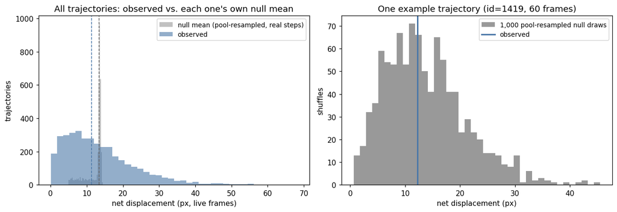

## Flower plots: real vs. one pool-resampled realization

Both panels re-base each trajectory to a common origin (its own start = (0,0)). The null panel's path is built from real steps drawn at random from the whole-population pool (not fabricated angles), so any coherent look in the real panel reflects genuine directional persistence, not an artifact of the null construction.

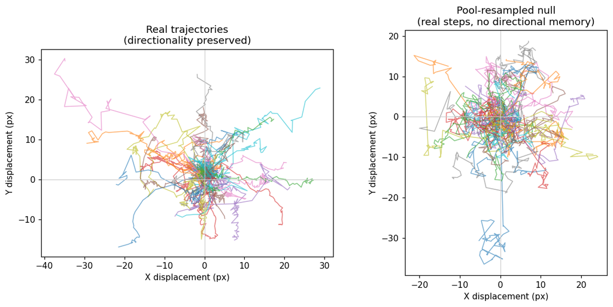

## Bonus: turning-angle persistence

Autocorrelation of step heading vs. lag — real motion should decay slower than the null (which is flat near 0 by construction).

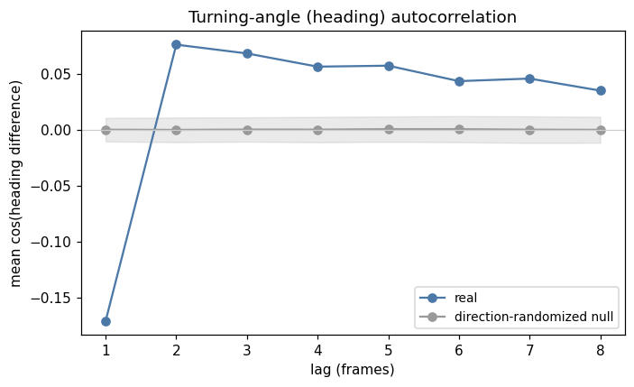

|  | lag | real_mean | null_mean | null_std |
| --- | --- | --- | --- | --- |
| 0 | 1 | -0.171016 | 0.000335 | 0.010544 |
| 1 | 2 | 0.076488 | 0.000153 | 0.011034 |
| 2 | 3 | 0.068609 | 0.000467 | 0.010890 |
| 3 | 4 | 0.056782 | 0.000407 | 0.011371 |
| 4 | 5 | 0.057649 | 0.000794 | 0.011338 |
| 5 | 6 | 0.043809 | 0.000799 | 0.011706 |
| 6 | 7 | 0.046111 | 0.000367 | 0.011891 |
| 7 | 8 | 0.035329 | 0.000227 | 0.011634 |

### Is the turning-angle persistence actually significant?

The plot above shows real vs. null autocorrelation curves, but no formal test yet. Since each trajectory has both a real value and its own null mean (averaged over resamples) at every lag, this is a paired comparison -- same Wilcoxon signed-rank approach as the displacement test above, run separately per lag.

|  | lag | n | statistic | p_value | median_diff |
| --- | --- | --- | --- | --- | --- |
| 0 | 1 | 3521 | 603506.0 | 1.000000e+00 | -0.196560 |
| 1 | 2 | 3521 | 4820008.0 | 4.643464e-179 | 0.073080 |
| 2 | 3 | 3521 | 4703330.0 | 6.782679e-156 | 0.066483 |
| 3 | 4 | 3521 | 4470368.0 | 1.695341e-114 | 0.052242 |
| 4 | 5 | 3521 | 4519866.0 | 9.425528e-123 | 0.054306 |
| 5 | 6 | 3521 | 4172210.0 | 6.060609e-71 | 0.043154 |
| 6 | 7 | 3521 | 4241207.0 | 4.414574e-80 | 0.043941 |
| 7 | 8 | 3521 | 4025028.0 | 2.411394e-53 | 0.034457 |

## Caveats: could technical error explain some of this?

The effect sizes throughout this notebook are small (a fraction of a pixel, a few hundredths of a correlation coefficient) -- exactly the regime where segmentation noise, tracking mistakes, or mislinking can masquerade as biology. Worth checking directly rather than assuming either way.

```
post-fixation 'should be still' steps: n=7,611, median=0.999 px
live steps: n=184,214, median=1.049 px
noise floor as a fraction of the live median step: 95%
```

**This came out higher than expected: the post-fixation "should be motionless" median step is ~95% of the live median step size.** That doesn't mean 95% of *displacement* is noise (a persistent random walk vs. pure jitter have very different statistical signatures even at similar step magnitudes), but it does mean the raw per-step signal-to-noise ratio here is low, and is a very plausible explanation for the negative lag-1 turning-angle autocorrelation above -- independent per-frame localization noise is a textbook cause of exactly that artifact in single-particle tracking. Two more specific technical-error concerns:

- **Segmentation jitter.** Cellpose mask boundaries can shift slightly frame-to-frame for a perfectly stationary cell (sub-pixel to ~1px), which is comparable to the median live step (1.05px) -- see above.
- **Tracking/mislinking errors, especially under crowding.** The tracker's distance-fallback and gap-bridging stages (`pre/trajectories.py`) are more likely to mislink in dense regions. A wrong link would attribute a "step" to the wrong physical cell. This is a particular concern for NF03's crowding-slows-speed finding: if mislinking is *more common* in crowded regions and systematically produces smaller apparent displacement (e.g. a broken/restarted track looks slower than one continuous real track), that alone could produce "crowded cells look slower" as an artifact, without any real biology behind it.

**Next steps to rule this out**, roughly in order of effort:

1. `pre/trajectories.py`'s `track()` already records *how* each link was made (`method`: `"overlap"` vs. `"distance"` fallback). Re-run the key correlations (crowding vs. speed, shape-variability vs. speed) restricted to trajectories built entirely from confident overlap links, and check whether the effects survive.
2. Compare the noise-floor step-size distribution against the *live* step-size distribution directly (not just medians) -- if they're statistically indistinguishable in shape, that's a stronger signal the live data is noise-dominated at the single-step level.
3. Re-run NF01's displacement/turning-angle tests after a mild temporal smoothing (or a minimum-step threshold) on centroids, and see how much of the signal survives -- if it vanishes under smoothing, it was likely jitter.
4. Once the scrubber's search-by-id feature exists (queued separately), manually spot-check a sample of high-collision-count or high-shape-variability cells to visually confirm they're real tracked cells, not segmentation artifacts or mislinked identities.

## ⭐ Key finding

**No population-level excess net displacement** against the pool-resampled null (real steps only): Wilcoxon p = 0.050 (borderline), median(observed - null) = -0.42 px (n = 3,721 trajectories, >=10 live frames), 12.8% individually significant.

**Turning-angle persistence IS formally significant, lags 2-8** (paired Wilcoxon per lag, n=3,521 trajectories): p ranges from 4.6e-179 (lag 2) to 2.4e-53 (lag 8), median diff +0.03 to +0.07. Lag 1 is significant in the *opposite* direction (p=1.0 for "greater", i.e. real is below null there) -- consistent with measurement jitter, not real anti-persistence.

**Caveat, checked directly:** the post-fixation "should be motionless" step size (median 0.999px, frames 61-64) is **95% of the live median step size** (1.049px) -- the raw per-step signal-to-noise ratio is low, a very plausible driver of the negative lag-1 autocorrelation (a textbook artifact of localization noise in particle tracking). This doesn't invalidate the lag 2-8 result (a persistent random walk and pure jitter have different signatures even at similar step magnitudes), but it's a real reason for caution, and a specific concern for NF03's crowding-slows-speed finding if mislinking is more common in crowded regions. See the caveats section above for concrete next steps (overlap-only vs. distance-fallback comparison, smoothing sensitivity, manual spot-checks).